# Classification of data from a particular news collection into categories such as international news and travel using machine learning and deep learning. Short description of the news dataset is used for the machine learning with category as a target.

Importing the required Statements

```python
from sklearn.model_selection import cross_val_score
import pandas as pandasForSortingCSV
import nltk
import re
import string
import matplotlib
import numpy as np
from nltk import *
from nltk.corpus import stopwords
import pandas as pd
import matplotlib.pyplot as plt
import gensim
from sklearn.linear_model import LogisticRegressionCV
from nltk.stem.porter import PorterStemmer
from nltk.stem.snowball import SnowballStemmer
from nltk.stem.wordnet import WordNetLemmatizer
import pickle
from pandas import DataFrame as df
from datetime import datetime
from IPython.display import display_html
import matplotlib.pyplot as plt
import seaborn as sns
from sklearn import preprocessing
from sklearn.model_selection import train_test_split
from sklearn import metrics
from sklearn.metrics import confusion_matrix
from sklearn.feature_extraction.text import CountVectorizer
from sklearn.feature_extraction.text import TfidfVectorizer
from sklearn.model_selection import train_test_split
from sklearn.metrics import accuracy_score
from sklearn.model_selection import KFold
from sklearn.metrics import classification_report
from sklearn.metrics import make_scorer, roc_curve, roc_auc_score
from sklearn.metrics import precision_recall_fscore_support as score
from sklearn.metrics.pairwise import cosine_similarity
from sklearn.multiclass import OneVsRestClassifier
from sklearn.linear_model import LogisticRegression
from sklearn.svm import SVC, LinearSVC
from sklearn.tree import DecisionTreeClassifier
from sklearn.ensemble import RandomForestClassifier
from sklearn.neighbors import KNeighborsClassifier
from sklearn.naive_bayes import GaussianNB,MultinomialNB,BernoulliNB
import tensorflow as tf
import tensorflow_hub as hub
import numpy as np
import os
import pandas as pd
import re
import keras.layers as layers
from collections import Counter
from keras import backend as K
from keras.callbacks import TensorBoard
from keras.layers import Input, Embedding, BatchNormalization, LSTM, Dense, Concatenate , Dropout
from keras.models import Model
from keras.utils import plot_model
from keras.preprocessing.text import Tokenizer
from keras_preprocessing.sequence import pad_sequences
from sklearn.model_selection import train_test_split
from keras.utils import to_categorical
import copy
import numpy as np
import matplotlib.pyplot as plt
from sklearn.metrics import accuracy_score
from keras import optimizers
from keras import regularizers
```

## Task 1

### 2.Loading my dataset

```python
mydata=pd.read_csv('21204205.csv', encoding='Latin1',dtype=str)
```

Editing my dataset with preffered column names

```python
mydata = mydata.set_axis(["id","category","headline","authors","link","short_description","date"],axis=1)
```

Viewing the dataset

```python
mydata
```

|  | id | category | headline | authors | link | short_description | date |
| --- | --- | --- | --- | --- | --- | --- | --- |
| 0 | 0 | WORLD NEWS | South Korea Working To Formally End The Korean... | Nick Visser | https://www.huffingtonpost.com/entry/south-kor... | For more than 60 years, an official peace trea... | 2018-04-19 |
| 1 | 1 | TRAVEL | Savor the South at One of These Summer Festivals | Carolyn Bass, ContributorWriter, traveler, foo... | https://www.huffingtonpost.com/entry/savor-the... | Georgia's private Sea Island will open to the ... | 2015-05-22 |
| 2 | 2 | WORLD NEWS | Storm Surge Warnings Issued For Gulf Coast As ... | NaN | https://www.huffingtonpost.com/entry/tropical-... | The storm has already killed 22 people in Cent... | 2017-10-06 |
| 3 | 3 | TRAVEL | Panama City Is Central America's Past And Futu... | Mark Chesnut, Contributor\nFounder and editor,... | https://www.huffingtonpost.com/entry/hot-spot-... | In Panama City, high rise steel looms over tin... | 2013-01-16 |
| 4 | 4 | TRAVEL | Things to Do in the Land of the Royal Family | FlipKey, Contributor\nVacation rental marketplace | https://www.huffingtonpost.com/entry/things-to... | With all the royal baby excitement, we're just... | 2013-07-22 |
| ... | ... | ... | ... | ... | ... | ... | ... |
| 7995 | 7995 | TRAVEL | World's Most Dangerous Path Undergoing Safety ... | Carly Ledbetter | https://www.huffingtonpost.com/entry/worlds-mo... | The part of the pathway that is deteriorating ... | 2014-03-27 |
| 7996 | 7996 | TRAVEL | Epic Pictures Of Bolivia's Salt Flats Prove It... | Gabriela Kruschewsky | https://www.huffingtonpost.com/entry/bolivia-s... | Travelers flock to South America by the planel... | 2014-02-03 |
| 7997 | 7997 | TRAVEL | Zihuatenejo: Still Mexico's Best Kept Secret | Max Gladwell, ContributorThe Nexus of Entrepre... | https://www.huffingtonpost.com/entry/zihuatene... | When I think of an ideal beach vacation, I thi... | 2015-06-25 |
| 7998 | 7998 | WORLD NEWS | India Test-Fires Nuclear-Capable ICBM | Willa Frej | https://www.huffingtonpost.com/entry/india-icb... | The new missile has a range of more than 3,000... | 2018-01-18 |
| 7999 | 7999 | WORLD NEWS | Theresa May Secures Deal With Northern Ireland... | Jesselyn Cook | https://www.huffingtonpost.com/entry/theresa-m... | Here's what you need to know about the Democra... | 2017-06-09 |

8000 rows × 7 columns

## 3. iii) Removing the nan values and duplicates from the dataset since its a common occurence for the data to have duplicate values and empty values

```python
mydata=mydata.dropna()
mydata=mydata.drop_duplicates()
mydata
```

|  | id | category | headline | authors | link | short_description | date |
| --- | --- | --- | --- | --- | --- | --- | --- |
| 0 | 0 | WORLD NEWS | South Korea Working To Formally End The Korean... | Nick Visser | https://www.huffingtonpost.com/entry/south-kor... | For more than 60 years, an official peace trea... | 2018-04-19 |
| 1 | 1 | TRAVEL | Savor the South at One of These Summer Festivals | Carolyn Bass, ContributorWriter, traveler, foo... | https://www.huffingtonpost.com/entry/savor-the... | Georgia's private Sea Island will open to the ... | 2015-05-22 |
| 3 | 3 | TRAVEL | Panama City Is Central America's Past And Futu... | Mark Chesnut, Contributor\nFounder and editor,... | https://www.huffingtonpost.com/entry/hot-spot-... | In Panama City, high rise steel looms over tin... | 2013-01-16 |
| 4 | 4 | TRAVEL | Things to Do in the Land of the Royal Family | FlipKey, Contributor\nVacation rental marketplace | https://www.huffingtonpost.com/entry/things-to... | With all the royal baby excitement, we're just... | 2013-07-22 |
| 5 | 5 | WORLD NEWS | Huge Fire Erupts At Tomorrowland Festival In S... | Dominique Mosbergen | https://www.huffingtonpost.com/entry/tomorrowl... | Videos show the main stage engulfed in flames. | 2017-07-30 |
| ... | ... | ... | ... | ... | ... | ... | ... |
| 7995 | 7995 | TRAVEL | World's Most Dangerous Path Undergoing Safety ... | Carly Ledbetter | https://www.huffingtonpost.com/entry/worlds-mo... | The part of the pathway that is deteriorating ... | 2014-03-27 |
| 7996 | 7996 | TRAVEL | Epic Pictures Of Bolivia's Salt Flats Prove It... | Gabriela Kruschewsky | https://www.huffingtonpost.com/entry/bolivia-s... | Travelers flock to South America by the planel... | 2014-02-03 |
| 7997 | 7997 | TRAVEL | Zihuatenejo: Still Mexico's Best Kept Secret | Max Gladwell, ContributorThe Nexus of Entrepre... | https://www.huffingtonpost.com/entry/zihuatene... | When I think of an ideal beach vacation, I thi... | 2015-06-25 |
| 7998 | 7998 | WORLD NEWS | India Test-Fires Nuclear-Capable ICBM | Willa Frej | https://www.huffingtonpost.com/entry/india-icb... | The new missile has a range of more than 3,000... | 2018-01-18 |
| 7999 | 7999 | WORLD NEWS | Theresa May Secures Deal With Northern Ireland... | Jesselyn Cook | https://www.huffingtonpost.com/entry/theresa-m... | Here's what you need to know about the Democra... | 2017-06-09 |

6428 rows × 7 columns

Checking whether there is any empty rows

```python
mydata.isnull().sum()
```

```
id                   0
category             0
headline             0
authors              0
link                 0
short_description    0
date                 0
dtype: int64
```

## Merging short description and headline into short description

```python
mydata["short_description"]=mydata['headline']+mydata['short_description']
```

### Preprocessing :Converting the whole dataset into lowercase

```python
mydata['short_description'] = mydata['short_description'].str.lower()
mydata['category'] = mydata['category'].str.lower()
mydata['headline'] =[word.lower() for word in mydata['headline']]
mydata['authors'] = [word.lower() for word in mydata['authors']]
mydata['link'] = [word.lower() for word in mydata['link']]
```

# Plotting the news data set as per category

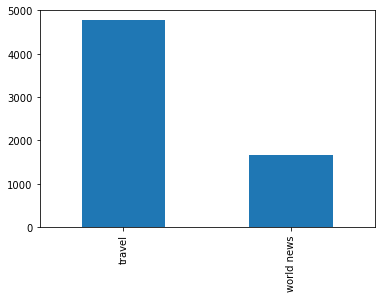

```python
mydata['category'].value_counts().plot(kind='bar')
```

## After plotting the dataset in relation to category we noticed there is a imbalance and not equally distributed which may lead to predicting the best accuracy scores in travel category and fail to predict exact accuracy in world news category

Separating the dataset as per the category "travel" and "world news"

```python
mydata_travel=mydata[mydata["category"] == 'travel']
mydata_news=mydata[mydata["category"] == 'world news']
```

## Considering the short description of the news dataset,Converting the string to a list

```python
# mydata_travel["short_description"].values.tolist()
# mydata_news["short_description"].values.tolist()
```

Defining Method to convert list to String

```python
#Method to convert list to String
def listToString(s):
    str1=" "
    return(str1.join(s))
```

### Preprocessing the data using nltk methods (Tokenization,punctuation and stop words removal)

```python
mydata_travel_token = nltk.word_tokenize(str(mydata_travel['short_description'].values.tolist()))
mydata_news_token= nltk.word_tokenize(str(mydata_news['short_description'].values.tolist()))
mydata_travel_no_punct = [t for t in mydata_travel_token if t.isalnum()]
mydata_news_no_punct=[t for t in mydata_news_token if t.isalnum()]
mydata_travel_no_stopwords = [t for t in mydata_travel_no_punct if t not in stopwords.words('english')]
mydata_news_no_stopwords= [t for t in mydata_news_no_punct if t not in stopwords.words('english')]
```

## 3.i) Using Frequency distrubution finding the most common words in travel category

```python
fd_travel = nltk.FreqDist(mydata_travel_no_stopwords)
print(fd_travel.most_common(10))
```

```
[('travel', 803), ('photos', 775), ('one', 569), ('new', 529), ('world', 525), ('best', 503), ('like', 407), ('city', 394), ('time', 371), ('get', 340)]
```

## 3.i) Using Frequency distrubution finding the most common words in news category

```python
fd_news = nltk.FreqDist(mydata_news_no_stopwords)
print(fd_news.most_common(10))
```

```
[('trump', 162), ('korea', 142), ('north', 133), ('said', 130), ('new', 123), ('people', 118), ('world', 107), ('president', 104), ('country', 96), ('says', 94)]
```

### 3.ii) Taking a copy of data to run feature selection using Chi-Square Test

```python
DATAAA = pd.DataFrame(mydata)
#Make a copy:
featureselection = DATAAA.copy()
print(featureselection)
```

```
        id    category                                           headline  \
0        0  world news  south korea working to formally end the korean...
1        1      travel   savor the south at one of these summer festivals
3        3      travel  panama city is central america's past and futu...
4        4      travel       things to do in the land of the royal family
5        5  world news  huge fire erupts at tomorrowland festival in s...
...    ...         ...                                                ...
7995  7995      travel  world's most dangerous path undergoing safety ...
7996  7996      travel  epic pictures of bolivia's salt flats prove it...
7997  7997      travel       zihuatenejo: still mexico's best kept secret
7998  7998  world news              india test-fires nuclear-capable icbm
7999  7999  world news  theresa may secures deal with northern ireland...

                                                authors  \
0                                           nick visser
```

[output cut: 38 more lines]

```python
del featureselection["date"]
del featureselection["headline"]
del featureselection["authors"]
del featureselection["link"]
```

[figure not shown]

```python
contigency= pd.crosstab(featureselection['short_description'], featureselection['category'])
contigency_pct = pd.crosstab(featureselection['short_description'], featureselection['category'], normalize='index')
plt.figure(figsize=(12,8))
sns.heatmap(contigency, annot=True, cmap="YlGnBu")
```

### 3.iii) Length of sentences

Defining a function to find length of each sentence

```python
def sentence_length(text):
    sentences = text.split(",")
    words = text.split(" ")
    if(sentences[len(sentences)-1]==""):
       sentence_length = len(words)/len(sentences)-1
    else:
       sentence_length = len(words)/len(sentences)
    return sentence_length
#https://python-forum.io/thread-11585.html
```

```python
travel_avg=sentence_length(str(mydata_travel['short_description'].values.tolist()))
news_avg=sentence_length(str(mydata_news['short_description'].values.tolist()))
```

Average of sentences in category "travel"

```python
print(travel_avg)
```

```
13.349929982884705
```

Average of sentences in category "world news"

```python
print(news_avg)
```

```
13.915276851234156
```

Viewing the columns of our data set

```python
mydata.columns
```

```
Index(['id', 'category', 'headline', 'authors', 'link', 'short_description',
       'date'],
      dtype='object')
```

# Task 2

# Encoding the Category "World news as 0" and "Travel as 1"

```python
possible_category = mydata.category.unique()

label_dict = {}
for index, possible_categor in enumerate(possible_category):
    label_dict[possible_categor] = index
label_dict
```

```
{'world news': 0, 'travel': 1}
```

## Vectorizing the category id and category to be used as target while running classifiers

```python
mydata['c_id'] = mydata.category.replace(label_dict)
mydata['category'] = mydata.category.replace(label_dict)
```

```python
mydata
```

|  | id | category | headline | authors | link | short_description | date | c_id |
| --- | --- | --- | --- | --- | --- | --- | --- | --- |
| 0 | 0 | 0 | south korea working to formally end the korean... | nick visser | https://www.huffingtonpost.com/entry/south-kor... | south korea working to formally end the korean... | 2018-04-19 | 0 |
| 1 | 1 | 1 | savor the south at one of these summer festivals | carolyn bass, contributorwriter, traveler, foo... | https://www.huffingtonpost.com/entry/savor-the... | savor the south at one of these summer festiva... | 2015-05-22 | 1 |
| 3 | 3 | 1 | panama city is central america's past and futu... | mark chesnut, contributor\nfounder and editor,... | https://www.huffingtonpost.com/entry/hot-spot-... | panama city is central america's past and futu... | 2013-01-16 | 1 |
| 4 | 4 | 1 | things to do in the land of the royal family | flipkey, contributor\nvacation rental marketplace | https://www.huffingtonpost.com/entry/things-to... | things to do in the land of the royal familywi... | 2013-07-22 | 1 |
| 5 | 5 | 0 | huge fire erupts at tomorrowland festival in s... | dominique mosbergen | https://www.huffingtonpost.com/entry/tomorrowl... | huge fire erupts at tomorrowland festival in s... | 2017-07-30 | 0 |
| ... | ... | ... | ... | ... | ... | ... | ... | ... |
| 7995 | 7995 | 1 | world's most dangerous path undergoing safety ... | carly ledbetter | https://www.huffingtonpost.com/entry/worlds-mo... | world's most dangerous path undergoing safety ... | 2014-03-27 | 1 |
| 7996 | 7996 | 1 | epic pictures of bolivia's salt flats prove it... | gabriela kruschewsky | https://www.huffingtonpost.com/entry/bolivia-s... | epic pictures of bolivia's salt flats prove it... | 2014-02-03 | 1 |
| 7997 | 7997 | 1 | zihuatenejo: still mexico's best kept secret | max gladwell, contributorthe nexus of entrepre... | https://www.huffingtonpost.com/entry/zihuatene... | zihuatenejo: still mexico's best kept secretwh... | 2015-06-25 | 1 |
| 7998 | 7998 | 0 | india test-fires nuclear-capable icbm | willa frej | https://www.huffingtonpost.com/entry/india-icb... | india test-fires nuclear-capable icbmthe new m... | 2018-01-18 | 0 |
| 7999 | 7999 | 0 | theresa may secures deal with northern ireland... | jesselyn cook | https://www.huffingtonpost.com/entry/theresa-m... | theresa may secures deal with northern ireland... | 2017-06-09 | 0 |

6428 rows × 8 columns

### Splitting the dataset into X and y where X contains headline,authors,link,short description,date and category id

```python
X = mydata.iloc[:,2:8]
X.columns
```

```
Index(['headline', 'authors', 'link', 'short_description', 'date', 'c_id'], dtype='object')
```

### Setting y as a target("category")

```python
y = mydata['category']
print(y)
```

```
0       0
1       1
3       1
4       1
5       0
       ..
7995    1
7996    1
7997    1
7998    0
7999    0
Name: category, Length: 6428, dtype: int64
```

## 4.i) Specifying the size of the dataset and spliting the dataset into combined train plus valid datasets with size 0.75 and a test dataset with size 0.25

```python
X_train_plus_valid, X_test, y_train_plus_valid, y_test = train_test_split(X, y, random_state=0, test_size = 0.25, train_size = 0.75)
```

### 4.i)Then again splitting the combined train plus valid dataset into separate train with size 0.5 and valid datasets as 0.25

```python
X_train, X_valid, y_train, y_valid = train_test_split(X_train_plus_valid, y_train_plus_valid, random_state=0, test_size = 0.25/0.75, train_size = 0.5/0.75)
```

### 4.ii) Storing the dataset into Excel csv files for train,test and valid datasets

```python
X_train.to_csv('train.csv',index=False)
X_test.to_csv('test.csv',index=False)
X_valid.to_csv('valid.csv',index=False)
```

### 5.) Loading the train dataset

```python
train=pd.read_csv('train.csv')
train
```

|  | headline | authors | link | short_description | date | c_id |
| --- | --- | --- | --- | --- | --- | --- |
| 0 | how can you miss america's national parks if t... | christopher elliott, contributor\nauthor, how ... | https://www.huffingtonpost.com/entry/how-can-y... | how can you miss america's national parks if t... | 2013-10-21 | 1 |
| 1 | eating at the world's best restaurant: el cell... | scott adams, contributor\nadventure travel and... | https://www.huffingtonpost.com/entry/eating-at... | eating at the world's best restaurant: el cell... | 2014-04-10 | 1 |
| 2 | will the palestinians ever play their cards ri... | alon ben-meir, contributorsenior fellow, cente... | https://www.huffingtonpost.com/entry/will-the-... | will the palestinians ever play their cards ri... | 2017-10-12 | 0 |
| 3 | ciao, bella! where to find italy's sexy nightlife | party earth, contributor\ncontributor | https://www.huffingtonpost.com/entry/ciao-bell... | ciao, bella! where to find italy's sexy nightl... | 2013-07-26 | 1 |
| 4 | world's only flying eye hospital provides eye ... | madeline diamond | https://www.huffingtonpost.com/entry/flying-ey... | world's only flying eye hospital provides eye ... | 2016-07-08 | 1 |
| ... | ... | ... | ... | ... | ... | ... |
| 3209 | north korea says new u.n. sanctions an act of war | ben blanchard and hyonhee shin, reuters | https://www.huffingtonpost.com/entry/north-kor... | north korea says new u.n. sanctions an act of ... | 2017-12-24 | 0 |
| 3210 | there's a new skymall in town | suzy strutner | https://www.huffingtonpost.com/entry/skymall-r... | there's a new skymall in townwhen skymall shut... | 2015-04-01 | 1 |
| 3211 | what's new at waikiki's famed outrigger hotel ... | sandra thomas, contributor\nlifestyle & travel... | https://www.huffingtonpost.com/entry/whats-new... | what's new at waikiki's famed outrigger hotel ... | 2012-08-11 | 1 |
| 3212 | 5 mind-blowing natural sinkholes around the world | off track planet, contributor\nthe independent... | https://www.huffingtonpost.com/entry/5-mindblo... | 5 mind-blowing natural sinkholes around the wo... | 2013-12-06 | 1 |
| 3213 | should women travel solo? | leyla giray alyanak, contributor\npublisher, w... | https://www.huffingtonpost.com/entry/traveling... | should women travel solo?the fact that violenc... | 2013-02-18 | 1 |

3214 rows × 6 columns

Removing every columns other than short description to run classification models

```python
del train['authors']
del train['link']
del train['headline']
del train['date']
```

Loading the train dataset

```python
train
```

|  | short_description | c_id |
| --- | --- | --- |
| 0 | how can you miss america's national parks if t... | 1 |
| 1 | eating at the world's best restaurant: el cell... | 1 |
| 2 | will the palestinians ever play their cards ri... | 0 |
| 3 | ciao, bella! where to find italy's sexy nightl... | 1 |
| 4 | world's only flying eye hospital provides eye ... | 1 |
| ... | ... | ... |
| 3209 | north korea says new u.n. sanctions an act of ... | 0 |
| 3210 | there's a new skymall in townwhen skymall shut... | 1 |
| 3211 | what's new at waikiki's famed outrigger hotel ... | 1 |
| 3212 | 5 mind-blowing natural sinkholes around the wo... | 1 |
| 3213 | should women travel solo?the fact that violenc... | 1 |

3214 rows × 2 columns

### Preprocessing the train dataset like removing tags, special character and stop words to remove noise in the train dataset

```python
def remove_tags(text):
  remove = re.compile(r'')
  return re.sub(remove, '', text)
train['short_description'] = train['short_description'].apply(remove_tags)

def special_char(text):
  reviews = ''
  for x in text:
    if x.isalnum():
      reviews = reviews + x
    else:
      reviews = reviews + ' '
  return reviews
train['short_description'] = train['short_description'].apply(special_char)

def remove_stopwords(text):
  stop_words = set(stopwords.words('english'))
  words = word_tokenize(text)
  return " ".join([x for x in words if x not in stop_words])
train['short_description'] = train['short_description'].apply(remove_stopwords)

train
```

|  | short_description | c_id |
| --- | --- | --- |
| 0 | miss america national parks never go away vide... | 1 |
| 1 | eating world best restaurant el celler de roca... | 1 |
| 2 | palestinians ever play cards right current eff... | 0 |
| 3 | ciao bella find italy sexy nightlifemoyo la ma... | 1 |
| 4 | world flying eye hospital provides eye care ne... | 1 |
| ... | ... | ... |
| 3209 | north korea says new u n sanctions act warthe ... | 0 |
| 3210 | new skymall townwhen skymall shut earlier year... | 1 |
| 3211 | new waikiki famed outrigger hotel photos outri... | 1 |
| 3212 | 5 mind blowing natural sinkholes around worlda... | 1 |
| 3213 | women travel solo fact violence women endemic ... | 1 |

3214 rows × 2 columns

Vectorizing the Short description of train dataset using term frequency vectorizer

```python
tfidf_vecttrain = TfidfVectorizer(analyzer='word', max_features=6000)

x_tfidftrain = tfidf_vecttrain.fit_transform(train['short_description'])

x_featurestrain = pd.DataFrame(x_tfidftrain.toarray())
```

Splitiing the train dataset into train and test to run classifiers

```python
x_train, x_test, y_traint, y_testt = train_test_split(x_featurestrain, train['c_id'], test_size=.2)
```